# Лабораторная работа №8

Текстовой редактор vi

Ежова А. М.

Российский университет дружбы народов, Москва, Россия

Факультет физико-математических и естественных наук

31 марта 2003

# Информация

## Докладчик

- Ежова Алиса Михайловна
- студентка НБИбд-01-22
- Российский университет дружбы народов
- https://github.com/AlisaEzhova

[figure not shown]

# Вводная часть

## Актуальность

- Данная лабораторная работа актуально для студентов, кто хочет получить практические навыки работы с редактором vi.

## Цели и задачи

- Познакомиться с операционной системой Linux. Получить практические навыки работы с редактором vi, установленным по умолчанию практически во всех дистрибутивах.

## Материалы и методы

- Процессор `pandoc` для входного формата Markdown
- Результирующие форматы
  - `pdf`
  - `html`
- Автоматизация процесса создания: `Makefile`

# Создание презентации

## Процессор `pandoc`

- Pandoc: преобразователь текстовых файлов
- Сайт: https://pandoc.org/
- Репозиторий: https://github.com/jgm/pandoc

## Формат `pdf`

- Использование LaTeX
- Пакет для презентации: beamer
- Тема оформления: `metropolis`

## Код для формата `pdf`

```yaml
slide_level: 2
aspectratio: 169
section-titles: true
theme: metropolis
```

## Формат `html`

- Используется фреймворк [reveal.js](https://revealjs.com/)
- Используется [тема](https://revealjs.com/themes/) `beige`

## Код для формата `html`

- Тема задаётся в файле `Makefile`

```
REVEALJS_THEME = beige
```

# Результаты

## Получающиеся форматы

- Полученный `pdf`-файл можно демонстрировать в любой программе просмотра `pdf`
- Полученный `html`-файл содержит в себе все ресурсы: изображения, css, скрипты

## Содержание исследования

2. Нажала клавишу “i” и ввела текст:

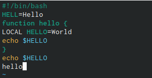

Текст

7. Вызвала “vi” на редактирование файла:

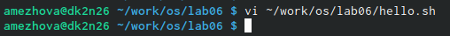

Команда для редактирования

11. Установила курсор на последней строке файла. Вставила после неё строку, содержащую следующий текст: echo $HELLO:

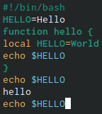

Вствка текста echo $HELLO

12. Удалила последнюю строку:

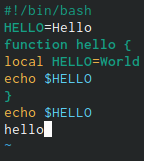

Удаление строки

13. Ввела команду отмены изменений “u” для отмены последней команды:

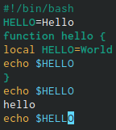

Команда отмены изменений

14. Ввела символ “:” для перехода в режим последней строки. Записала произведённые изменения и вышла из “vi”.

## Итоговый слайд

- В ходе выполнения лабораторной работы №8, я познакомилась с операционной системой Linux. Получила практические навыки работы с редактором vi, установленным по умолчанию практически во всех дистрибутивах.